# Wiskott-Aldrich syndrome protein

Fold-switch pair **2k42A_1ceeB** — **2k42A** vs **1ceeB**

Homo sapiens

## Figure 1: Phylogenetic tree with per-cluster fold-preference heatmap.

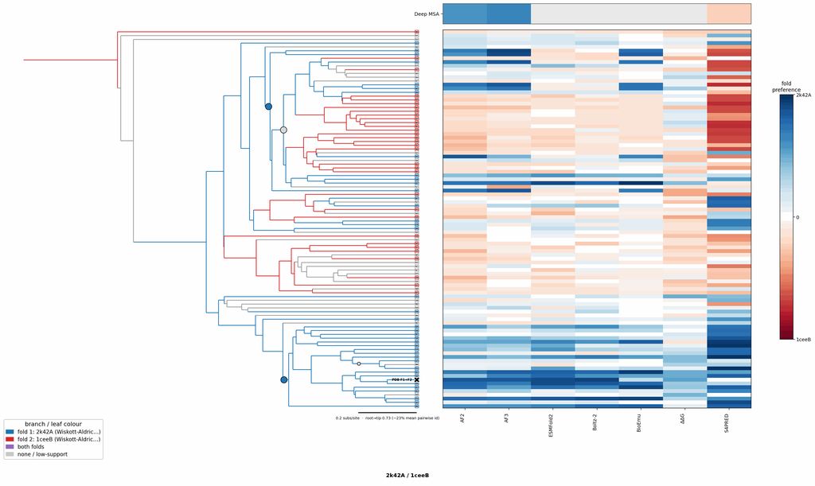

## Figure 2: Aligned overlay (both folds superposed)

The single fold-switching chain of each fold superposed by TM-align; waters hidden, any ligand shown as green sticks. Grey = structurally conserved core, colour = divergent (fold-switching) region.

2k42A (Wiskott-Aldrich syndrome protein) · dimer1ceeB (Wiskott-Aldrich syndrome protein) · dimerLigand GCP (bound to 1ceeB)

TM-score: 0.285 · Trigger class: mutation

Aligned overlay

Loading...

## Figure 3: The two folds, side by side

Each fold is coloured by per-residue Cα deviation between the two superposed structures: grey ≈ conserved core, full colour = structurally divergent (fold-switching) region.

2k42A (Wiskott-Aldrich syndrome protein)

1ceeB (Wiskott-Aldrich syndrome protein)

0 Å5≥10 Å

2k42A (Wiskott-Aldrich syndrome protein)

Loading...

1ceeB (Wiskott-Aldrich syndrome protein)

Loading...

## Figure 4: Best-cluster predicted contact maps over the two true folds.

Predicted contact maps (MSA-Transformer) for the clusters best matching each fold, over the true contacts of fold 1 (upper triangle) and fold 2 (lower). Divergent contacts between clusters are the contact-level signature of fold-switching.

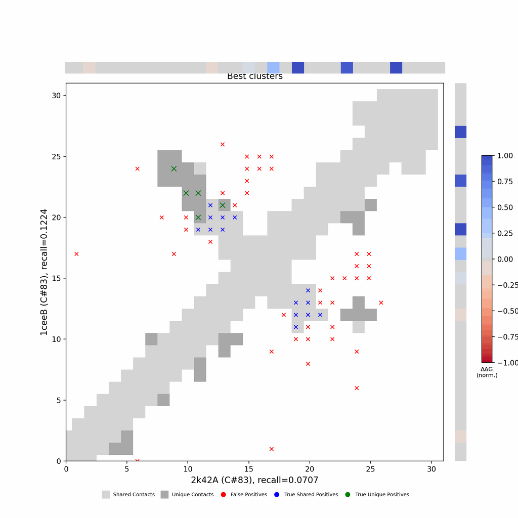

## Figure 5: Per-residue ΔΔG fold-preference contribution

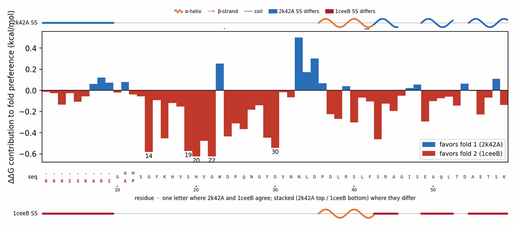

**More figures**

## Figure 6: Deep-MSA contact map panel / Best clusters contact map panel

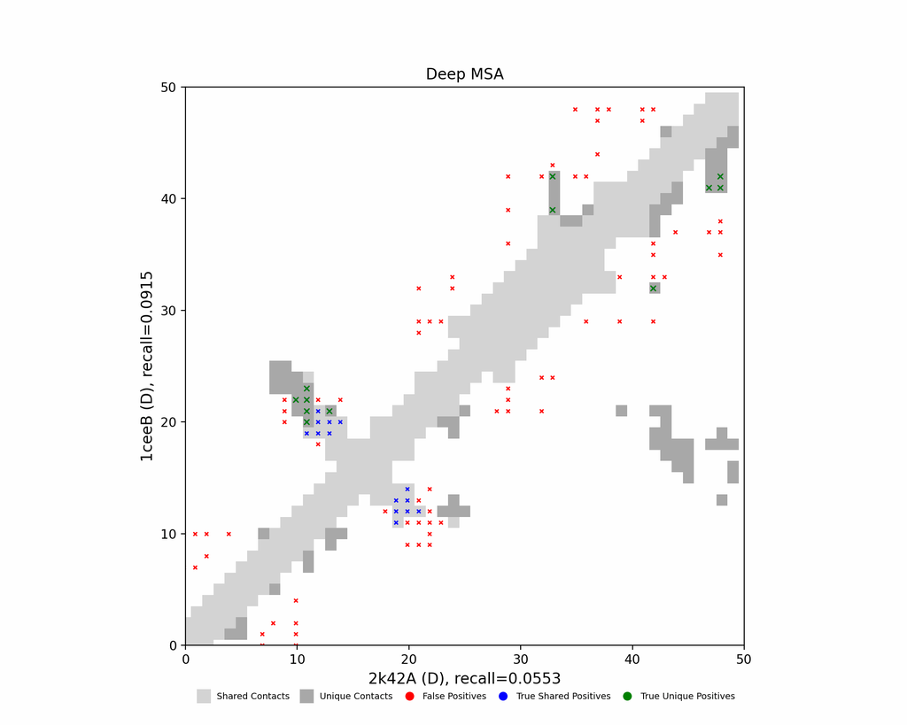

Deep-MSA contact map panel

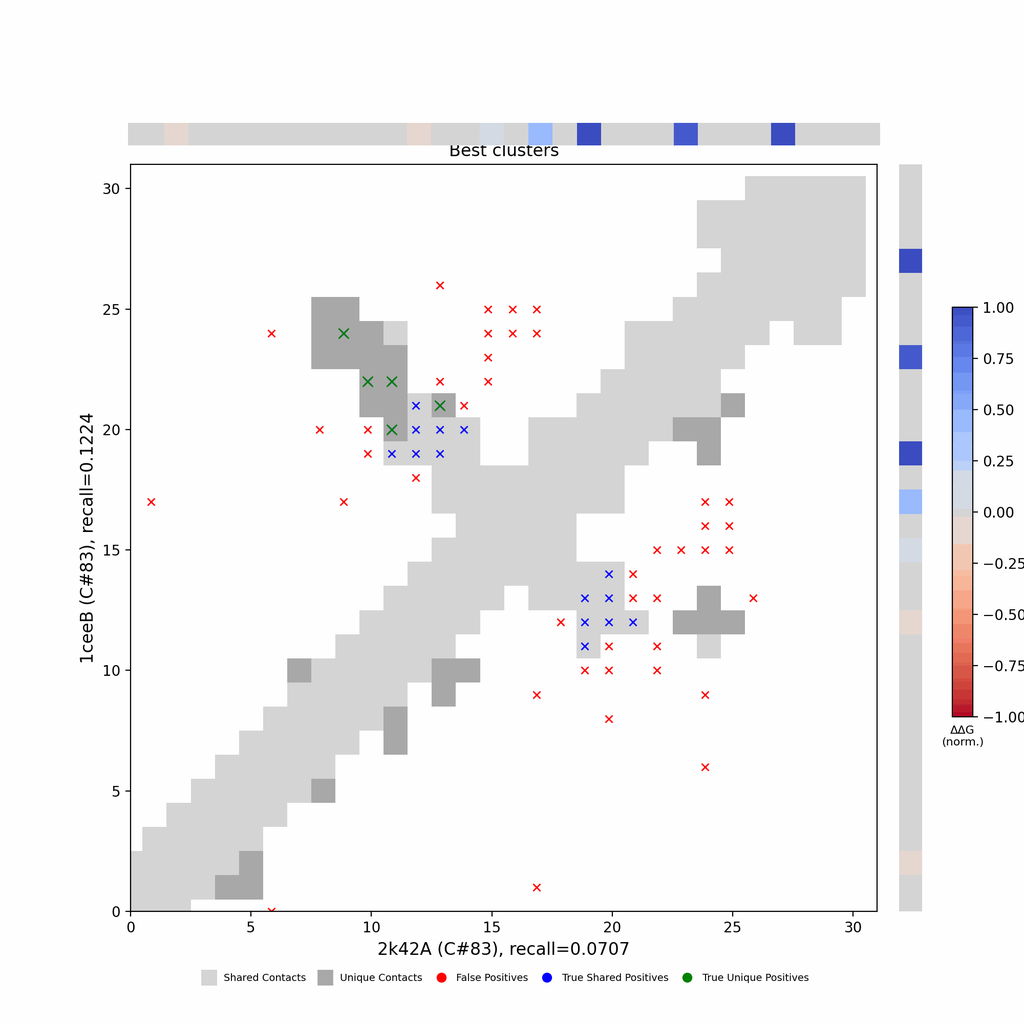

Best clusters contact map panel

## Figure 7: All clusters contact-map mosaic (small multiples).

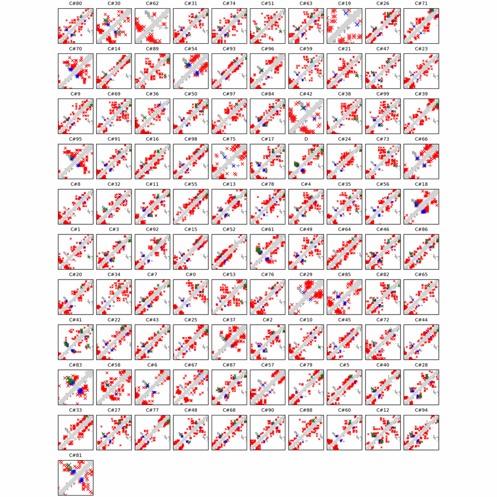

## Figure 8: Phylo null: tree with shuffled cluster fold labels.

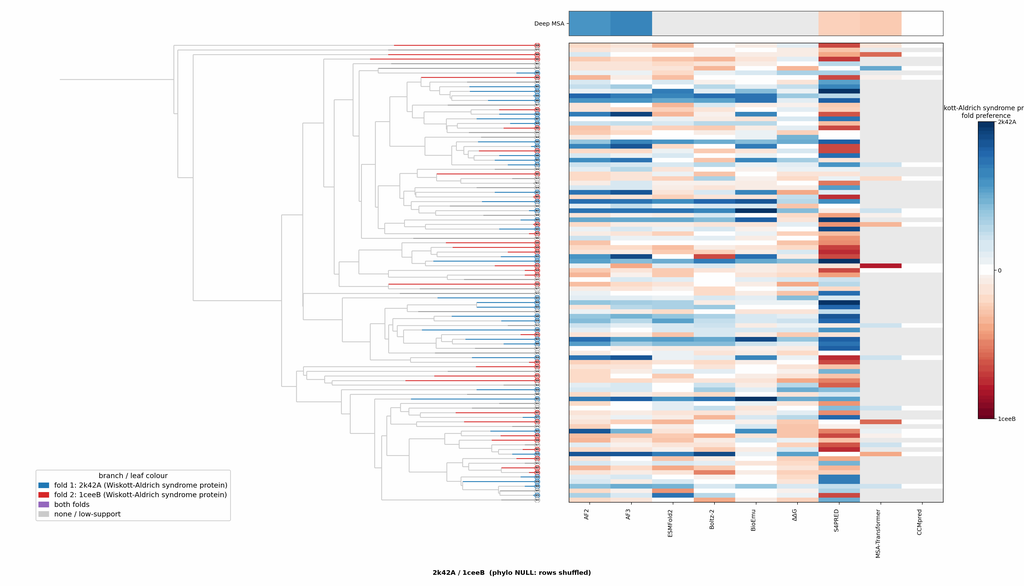

## Cluster metrics table

Per-cluster metrics underlying the figures above.

| cluster | n | neff | AF2_TM1 | AF2_TM2 | AF3_TM1 | AF3_TM2 | RE-MSAT-COM | RE-MSAT1 | RE-MSAT2 | ESM_SEQIDS | ESM_TM1 | ESM_TM2 | ΔΔG_Bias | ΔΔG_Bias_std | ΔΔG_frac_F1 | Boltz2_pref | S4PRED_pref | CCMpred_pref | BioEmu_pref |
| --- | --- | --- | --- | --- | --- | --- | --- | --- | --- | --- | --- | --- | --- | --- | --- | --- | --- | --- | --- |
| Deep | - | - | 0.79 | 0.48 | 0.82 | 0.46 | 0.38 | 0.17 | 0.3 | - | - | - | - | - | - | - | -0.07 | 0.0 | - |
| 000 | 277.0 | 138.0 | 0.43 | 0.28 | 0.36 | 0.31 | 0.17 | 0.06 | 0.19 | 006; 006; 001; 001; 002; 005; 002; 005; 010; 010 | 0.45 ± 0.04 | 0.28 ± 0.04 | -9.55 | 5.94 | 0.1 | 0.07 | -0.16 | 0.0 | 0.01 |
| 001 | 172.0 | 98.0 | 0.28 | 0.28 | 0.23 | 0.31 | 0.0 | 0.0 | 0.0 | 001; 001; 003; 003; 004; 004; 002; 002; 006; 006 | 0.50 ± 0.14 | 0.25 ± 0.02 | -11.77 | 3.72 | 0.0 | 0.02 | -0.04 | 0.0 | 0.01 |
| 002 | 154.0 | 56.0 | 0.2 | 0.24 | 0.25 | 0.24 | 0.11 | 0.04 | 0.05 | 002; 004; 004; 002; 003; 003; 001; 001; 005; 005 | 0.38 ± 0.03 | 0.38 ± 0.05 | -7.3 | 3.34 | 0.0 | -0.03 | -0.17 | 0.0 | -0.02 |
| 003 | 143.0 | 29.0 | 0.15 | 0.24 | 0.18 | 0.28 | 0.0 | 0.0 | 0.0 | 001; 001; 002; 002; 003; 003; 005; 005; 009; 004 | 0.53 ± 0.14 | 0.28 ± 0.03 | -12.11 | 3.8 | 0.0 | -0.06 | -0.24 | 0.0 | -0.03 |
| 004 | 115.0 | 29.0 | 0.62 | 0.31 | 0.6 | 0.28 | 0.0 | 0.0 | 0.0 | 003; 003; 002; 002; 001; 010; 001; 010; 005; 005 | 0.41 ± 0.04 | 0.33 ± 0.03 | -6.64 | 2.57 | 0.0 | 0.26 | 0.04 | 0.0 | 0.14 |
| 005 | 113.0 | 27.0 | 0.82 | 0.29 | 0.81 | 0.5 | 0.0 | 0.0 | 0.0 | 002; 002; 003; 009; 009; 003; 004; 004; 008; 008 | 0.38 ± 0.02 | 0.32 ± 0.03 | -12.35 | 4.58 | 0.0 | 0.06 | -0.19 | 0.0 | 0.19 |
| 006 | 111.0 | 22.0 | 0.19 | 0.3 | 0.24 | 0.23 | 0.0 | 0.0 | 0.0 | 001; 001; 007; 007; 003; 003; 004; 004; 009; 009 | 0.54 ± 0.15 | 0.27 ± 0.04 | -8.21 | 3.64 | 0.0 | 0.01 | -0.24 | 0.0 | -0.04 |
| 007 | 110.0 | 8.0 | 0.79 | 0.31 | 0.74 | 0.3 | 0.0 | 0.0 | 0.0 | 004; 004; 001; 001; 005; 005; 003; 003; 009; 009 | 0.38 ± 0.06 | 0.28 ± 0.03 | -2.49 | 3.74 | 0.3 | 0.41 | -0.06 | 0.0 | 0.27 |
| 008 | 109.0 | 25.0 | 0.31 | 0.3 | 0.29 | 0.26 | 0.0 | 0.0 | 0.0 | 001; 001; 002; 002; 003; 003; 005; 005; 004; 006 | 0.59 ± 0.10 | 0.26 ± 0.02 | -11.11 | 3.63 | 0.0 | 0.06 | -0.16 | 0.0 | 0.01 |
| 009 | 109.0 | 33.0 | 0.47 | 0.38 | 0.38 | 0.33 | 0.0 | 0.0 | 0.0 | 006; 006; 001; 001; 005; 005; 004; 004; 003; 002 | 0.39 ± 0.05 | 0.29 ± 0.04 | -8.81 | 3.72 | 0.0 | 0.17 | 0.09 | 0.0 | 0.0 |
| 010 | 107.0 | 61.0 | 0.29 | 0.28 | 0.25 | 0.28 | 0.1 | 0.04 | 0.05 | 001; 001; 002; 002; 003; 003; 005; 005; 006; 006 | 0.64 ± 0.12 | 0.29 ± 0.03 | -12.71 | 4.1 | 0.0 | -0.05 | -0.03 | 0.0 | -0.01 |
| 011 | 102.0 | 52.0 | 0.42 | 0.3 | 0.33 | 0.48 | 0.24 | 0.08 | 0.11 | 001; 001; 002; 002; 003; 006; 006; 003; 009; 005 | 0.56 ± 0.08 | 0.29 ± 0.03 | -10.47 | 5.01 | 0.0 | 0.06 | -0.08 | 0.0 | 0.01 |
| 012 | 97.0 | 55.0 | 0.48 | 0.29 | 0.38 | 0.28 | 0.47 | 0.23 | 0.22 | 003; 003; 005; 005; 004; 004; 001; 001; 002; 002 | 0.60 ± 0.06 | 0.33 ± 0.03 | -7.87 | 4.14 | 0.0 | 0.13 | -0.06 | 0.0 | 0.02 |
| 013 | 96.0 | 20.0 | 0.48 | 0.28 | 0.39 | 0.26 | 0.33 | 0.08 | 0.13 | 001; 001; 007; 007; 003; 006; 006; 009; 003; 002 | 0.26 ± 0.07 | 0.23 ± 0.04 | -6.85 | 3.9 | 0.0 | 0.16 | 0.14 | 0.0 | 0.03 |
| 014 | 92.0 | 20.0 | 0.79 | 0.32 | 0.79 | 0.26 | 0.0 | 0.0 | 0.0 | 004; 004; 003; 003; 002; 002; 001; 001; 007; 007 | 0.65 ± 0.15 | 0.29 ± 0.02 | -7.75 | 2.87 | 0.0 | 0.06 | -0.26 | 0.0 | 0.2 |
| 015 | 92.0 | 14.0 | 0.28 | 0.31 | 0.27 | 0.31 | 0.0 | 0.0 | 0.0 | 003; 003; 001; 002; 005; 001; 005; 002; 006; 006 | 0.62 ± 0.09 | 0.30 ± 0.01 | -10.95 | 3.36 | 0.0 | 0.09 | -0.02 | 0.0 | -0.01 |
| 016 | 86.0 | 1.0 | 0.82 | 0.28 | 0.8 | 0.3 | 0.0 | 0.0 | 0.0 | 001; 001; 002; 002; 006; 006; 004; 004; 003; 003 | 0.55 ± 0.11 | 0.28 ± 0.01 | -0.91 | 0.74 | 0.1 | 0.49 | -0.03 | 0.0 | 0.07 |
| 017 | 83.0 | 61.0 | 0.42 | 0.28 | 0.32 | 0.29 | 0.18 | 0.06 | 0.14 | 002; 001; 001; 002; 007; 007; 009; 009; 010; 010 | 0.38 ± 0.04 | 0.30 ± 0.04 | -11.51 | 5.62 | 0.0 | -0.02 | -0.23 | 0.0 | 0.0 |
| 018 | 83.0 | 19.0 | 0.18 | 0.21 | 0.2 | 0.24 | 0.0 | 0.0 | 0.0 | 001; 004; 001; 004; 005; 005; 002; 002; 006; 003 | 0.54 ± 0.08 | 0.27 ± 0.03 | -7.13 | 2.09 | 0.0 | 0.02 | -0.24 | 0.0 | -0.02 |
| 019 | 82.0 | 15.0 | 0.2 | 0.26 | 0.23 | 0.27 | 0.0 | 0.0 | 0.0 | 007; 007; 006; 006; 001; 001; 002; 002; 003; 004 | 0.37 ± 0.06 | 0.30 ± 0.04 | -9.8 | 3.15 | 0.0 | 0.01 | -0.24 | 0.0 | -0.02 |
| 020 | 80.0 | 37.0 | 0.27 | 0.29 | 0.21 | 0.26 | 0.0 | 0.0 | 0.0 | - | - | - | -13.68 | 5.24 | 0.0 | -0.02 | -0.19 | - | -0.0 |
| 021 | 79.0 | 42.0 | 0.8 | 0.35 | 0.81 | 0.29 | 0.0 | 0.0 | 0.0 | - | - | - | -8.56 | 4.34 | 0.0 | 0.02 | -0.24 | - | 0.21 |
| 022 | 75.0 | 24.0 | 0.33 | 0.32 | 0.29 | 0.26 | 0.0 | 0.0 | 0.0 | - | - | - | -11.58 | 3.56 | 0.0 | -0.0 | -0.15 | - | 0.0 |
| 023 | 74.0 | 12.0 | 0.35 | 0.24 | 0.33 | 0.28 | 0.0 | 0.0 | 0.0 | - | - | - | -12.36 | 3.79 | 0.0 | -0.05 | 0.19 | - | 0.01 |
| 024 | 73.0 | 5.0 | 0.41 | 0.27 | 0.38 | 0.24 | 0.0 | 0.0 | 0.0 | - | - | - | -1.55 | 1.47 | 0.1 | 0.14 | 0.09 | - | 0.02 |
| 025 | 73.0 | 2.0 | 0.39 | 0.27 | 0.36 | 0.26 | 0.0 | 0.0 | 0.0 | - | - | - | -2.57 | 0.9 | 0.0 | 0.06 | 0.02 | - | 0.01 |
| 026 | 71.0 | 21.0 | 0.31 | 0.28 | 0.28 | 0.26 | 0.0 | 0.0 | 0.06 | - | - | - | -10.87 | 4.82 | 0.0 | 0.02 | -0.04 | - | -0.0 |
| 027 | 70.0 | 25.0 | 0.26 | 0.23 | 0.23 | 0.25 | 0.0 | 0.0 | 0.06 | - | - | - | -7.82 | 2.98 | 0.0 | -0.01 | -0.1 | - | -0.01 |
| 028 | 70.0 | 34.0 | 0.46 | 0.31 | 0.45 | 0.32 | 0.43 | 0.12 | 0.18 | - | - | - | -9.07 | 3.62 | 0.0 | 0.01 | 0.13 | - | 0.02 |

[output cut: 71 more lines]